# AE 06 - Brexit - Telling Different Stories with Data

Max Asmar

2026-03-20

## Introduction

In this application exercise, you’ll explore how the same data can tell different stories depending on how you visualize it. You’ll work with survey data about Brexit opinions across different regions of Great Britain.

**The key lesson:** The choices you make in creating visualizations (scales, proportions vs. counts, faceting vs. grouping) dramatically affect the story your visualization tells.

**In this application exercise, you will:**

- Work with factors using `fct_relevel()` and `fct_recode()`
- Create faceted visualizations
- Use free scales in faceting
- Calculate and visualize proportions
- Create grouped bar plots with `position = "dodge"`
- Format axis labels with the scales package
- Interpret how different visualizations tell different stories

**Estimated time:** 30-45 minutes

## Getting Started

### Fork and Clone Workflow

**Quick reminder:** Work in YOUR forked `application-exercises` repository.

1. Navigate to the `ae-06-brexit` folder in YOUR fork
2. Open `ae-06-brexit.Rmd`
3. Verify the `data` folder exists with `brexit.csv`
4. Update the YAML with your name
5. Knit to verify it works

## Packages

```r
library(tidyverse)
library(scales)  # For formatting axis labels (we'll use this in Exercise 2)
```

**What these packages do:** - **tidyverse:** Data wrangling and visualization - **scales:** Formatting numbers, percentages, and dates on plots

## The Survey

In September 2019, YouGov surveyed 1,639 GB adults with the following question:

> In hindsight, do you think Britain was right/wrong to vote to leave EU?
> - Right to leave
> - Wrong to leave
> - Don’t know

The data from the survey is in `data/brexit.csv`.

## Load the Data

```r
brexit <- read_csv("data/brexit.csv")
```

**Explore the data:**

```r
glimpse(brexit)
```

```
## Rows: 1,639
## Columns: 2
## $ opinion <chr> "Right", "Right", "Right", "Right", "Right", "Right", "Right",…
## $ region  <chr> "london", "london", "london", "london", "london", "london", "l…
```

```r
# See the first few rows
head(brexit)
```

```
## # A tibble: 6 × 2
##   opinion region
##   <chr>   <chr>
## 1 Right   london
## 2 Right   london
## 3 Right   london
## 4 Right   london
## 5 Right   london
## 6 Right   london
```

```r
# Count responses by region
brexit %>%
  count(region)
```

```
## # A tibble: 5 × 2
##   region             n
##   <chr>          <int>
## 1 london           197
## 2 midlands_wales   354
## 3 north            400
## 4 rest_of_south    547
## 5 scot             141
```

```r
# Count responses by opinion
brexit %>%
  count(opinion)
```

```
## # A tibble: 3 × 2
##   opinion        n
##   <chr>      <int>
## 1 Don't know   188
## 2 Right        664
## 3 Wrong        787
```

**Understanding the data:**

- Each row represents one survey respondent
- `region`: Which region of GB they’re from
- `opinion`: Their response (Wrong, Right, Don’t know)

## Original Visualization

In the course video, we made the following visualisation. First, we need to clean up the region names and put them in a logical order.

```r
brexit <- brexit %>%
  # Reorder regions from south to north
  mutate(
    region = fct_relevel(region, "london", "rest_of_south",
                         "midlands_wales", "north", "scot"),
    # Rename regions with proper capitalization and spacing
    region = fct_recode(region,
                        London = "london",
                        `Rest of South` = "rest_of_south",
                        `Midlands / Wales` = "midlands_wales",
                        North = "north",
                        Scotland = "scot")
  )
```

**What this code does:**

- `fct_relevel()`: Changes the order of factor levels
- `fct_recode()`: Renames factor levels for better display
- Backticks `` `Rest of South` ``: Used for names with spaces

**Now create the original plot:**

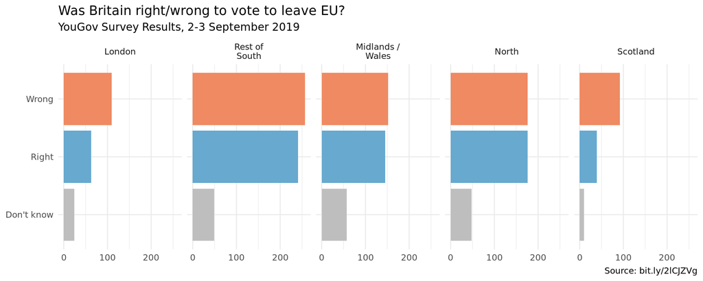

```r
ggplot(brexit, aes(y = opinion, fill = opinion)) +
  geom_bar() +
  facet_wrap(~region, nrow = 1, labeller = label_wrap_gen(width = 12)) +
  guides(fill = "none") +
  labs(
    title = "Was Britain right/wrong to vote to leave EU?",
    subtitle = "YouGov Survey Results, 2-3 September 2019",
    caption = "Source: bit.ly/2lCJZVg",
    x = NULL,
    y = NULL
  ) +
  scale_fill_manual(values = c(
    "Wrong" = "#ef8a62",
    "Right" = "#67a9cf",
    "Don't know" = "gray"
  )) +
  theme_minimal()
```

**What this plot shows:**

- Counts (not proportions) of each opinion
- Separated by region
- All facets use the same x-axis scale

## Exercise 1: Free Scales

Add `scales = "free_x"` as an argument to the `facet_wrap()` function. How does the visualisation change? How is the story this visualisation telling different than the story the original plot tells?

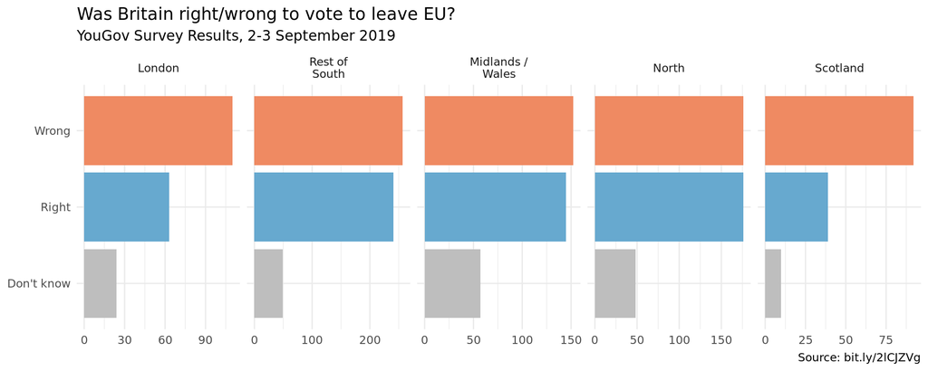

```r
# Remember to change eval=FALSE to eval=TRUE!

ggplot(brexit, aes(y = opinion, fill = opinion)) +
  geom_bar() +
  facet_wrap(~region,
    nrow = 1,
    labeller = label_wrap_gen(width = 12),
    scales = "free_x"  # Add "free_x" here
  ) +
  guides(fill = "none") +
  labs(
    title = "Was Britain right/wrong to vote to leave EU?",
    subtitle = "YouGov Survey Results, 2-3 September 2019",
    caption = "Source: bit.ly/2lCJZVg",
    x = NULL,
    y = NULL
  ) +
  scale_fill_manual(values = c(
    "Wrong" = "#ef8a62",
    "Right" = "#67a9cf",
    "Don't know" = "gray"
  )) +
  theme_minimal()
```

**What `scales = "free_x"` does:**

- Each facet gets its own x-axis scale
- The x-axis range is determined independently for each region
- Makes it easier to see proportions within each region

**Task 1.1:** How does the visualization change with free scales?

**Your answer:**

Using scales = “free_x” I am now able to have the data fill up most of each facet in the graph which allows me to better assess the distribution of “Wrong”, “Right”, and “Don’t know” opinions for the Brexit.

**Task 1.2:** How is the story this visualization tells different from the original plot?

**Your answer:**

**Original plot emphasizes:** The original plot emphasizes the quantity of votes for each region (facet).

**Free scales plot emphasizes:** The free scales plot emphasizes the relative proportions of votes for each region (facet).

**Task 1.3:** Which visualization would be misleading if you wanted to compare the absolute number of responses across regions? Why?

**Your answer:**

The free scales plot would be misleading if I wanted to compare the absolute number of responses across regions because the free scales plot does not standardize the scale across regions. For example, in the free scales plot, at a first glance it appears that the number of votes in London was equal to the number of votes in the Rest of South whereas in the original plot the rest of the South it is significantly easier to determine that there are more votes because the bars are bigger.

## Exercise 2: Comparing Proportions Across Facets

First, calculate the proportion of wrong, right, and don’t know answers in each category and then plot these proportions (rather than the counts). Then improve axis labeling.

**How is the story this visualisation telling different than the story the original plot tells?**

**Task 2.1:** Calculate proportions by region and opinion.

```r
# Remember to change eval=FALSE to eval=TRUE!

brexit_prop <- brexit %>%
  count(region, opinion) %>%           # Count by region and opinion
  group_by(region) %>%             # Group by region
  mutate(prop = n / sum(n))   # Calculate proportion within each region

brexit_prop
```

```
## # A tibble: 15 × 4
## # Groups:   region [5]
##    region           opinion        n   prop
##    <fct>            <chr>      <int>  <dbl>
##  1 London           Don't know    24 0.122
##  2 London           Right         63 0.320
##  3 London           Wrong        110 0.558
##  4 Rest of South    Don't know    49 0.0896
##  5 Rest of South    Right        241 0.441
##  6 Rest of South    Wrong        257 0.470
##  7 Midlands / Wales Don't know    57 0.161
##  8 Midlands / Wales Right        145 0.410
##  9 Midlands / Wales Wrong        152 0.429
## 10 North            Don't know    48 0.12
## 11 North            Right        176 0.44
## 12 North            Wrong        176 0.44
## 13 Scotland         Don't know    10 0.0709
## 14 Scotland         Right         39 0.277
## 15 Scotland         Wrong         92 0.652
```

**Hints:**

- Use `count(region, opinion)`
- Group by `region`
- Calculate proportion: `n / sum(n)`

**What this creates:**

- A new dataset with proportions instead of counts
- Each region’s proportions sum to 1 (100%)

**Task 2.2:** Plot the proportions with improved axis labeling.

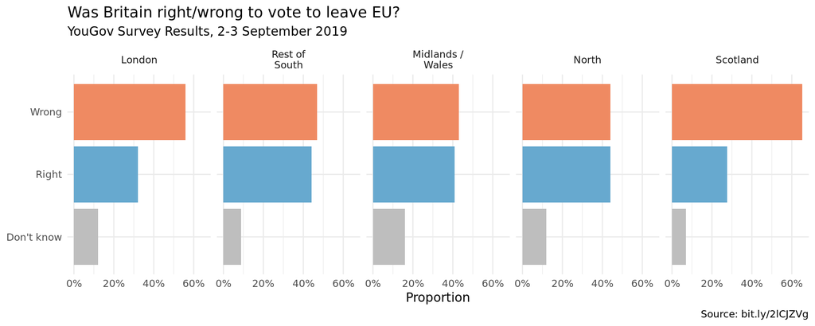

```r
# Remember to change eval=FALSE to eval=TRUE!

ggplot(brexit_prop, aes(y = opinion, x = prop, fill = opinion)) +
  geom_col() +                  # Use geom_col() for already-calculated values
  facet_wrap(~region, nrow = 1, labeller = label_wrap_gen(width = 12)) +
  guides(fill = "none") +
  labs(
    title = "Was Britain right/wrong to vote to leave EU?",
    subtitle = "YouGov Survey Results, 2-3 September 2019",
    caption = "Source: bit.ly/2lCJZVg",
    x = "Proportion",                  # Label for proportions
    y = NULL
  ) +
  scale_fill_manual(values = c(
    "Wrong" = "#ef8a62",
    "Right" = "#67a9cf",
    "Don't know" = "gray"
  )) +
  scale_x_continuous(labels = percent_format()) +  # Format x-axis as percentages
  theme_minimal()
```

**Hints:**

- x-axis should be `prop`
- x-axis label: something like “Proportion” or “Percentage”
- For percentage labels: `labels = percent_format()`
- Use `geom_col()` not `geom_bar()` because we already calculated the values

**Task 2.3:** How is the story this plot tells different from the original?

**Your answer:**

**Original plot (counts) shows:** The original plot shows the number of “Wrong ,”Right”, and “Don’t know” votes for each region.

**Proportion plot shows:** The proportion plot shows the percentage of “Wrong”, “Right”, and “Don’t know’ votes for each region, out of the total number of votes for that region.

**Which regions have the most “Wrong” responses as a proportion?** Scotland has the most ““Wrong” responses as a proportion.

## Exercise 3: Comparing Proportions Across Bars

Recreate the same visualisation from the previous exercise, this time dodging the bars for opinion proportions for each region, rather than faceting by region. Then improve the legend.

**How is the story this visualisation telling different than the story the previous plot tells?**

**Task 3.1:** Create a dodged bar plot.

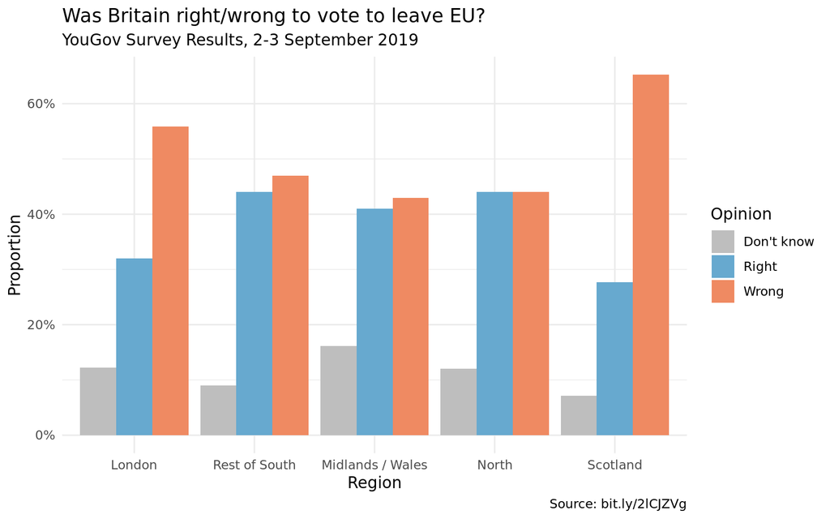

```r
# Remember to change eval=FALSE to eval=TRUE!

ggplot(brexit_prop, aes(x = region, y = prop, fill = opinion)) +
  geom_col(position = "dodge") +  # "dodge" makes bars side-by-side
  labs(
    title = "Was Britain right/wrong to vote to leave EU?",
    subtitle = "YouGov Survey Results, 2-3 September 2019",
    caption = "Source: bit.ly/2lCJZVg",
    x = "Region",                  # Region label
    y = "Proportion",                  # Proportion label
    fill = "Opinion"                # Better legend title
  ) +
  scale_fill_manual(values = c(
    "Wrong" = "#ef8a62",
    "Right" = "#67a9cf",
    "Don't know" = "gray"
  )) +
  scale_y_continuous(labels = percent_format()) +  # Format y-axis as percentages
  theme_minimal()
```

**Hints:**

- x-axis: `region`
- y-axis: `prop`
- fill: `opinion`
- position: `"dodge"` (makes bars side-by-side)
- x label: “Region”
- y label: “Proportion”
- fill label: “Opinion” or “Response”
- y-axis labels: `percent_format()`

**Task 3.2:** How is this visualization different from the faceted proportion plot?

**Your answer:**

**Faceted plot makes it easier to:** The faceted plot makes it easier to compare distributions within each facet.

**Dodged plot makes it easier to:** The dodged plot makes it easier to compare distributions across regions/groups.

**Task 3.3:** Which region shows the strongest opinion one way or the other (least “Don’t know”)?

**Your answer:** Scotland has the smallest percentage of “Don’t know” votes. Less than 10% of Scotland voters voted “Don’t know”.

## Exercise 4: Reflection on Data Storytelling

**Task 4.1:** You’re writing a report arguing that Scotland is most opposed to Brexit. Which visualization would you use? Why?

**Your answer:**

I would use the dodged plot because it is very intuitive to see that Scotland has the highest proportion of “Wrong” voters. I can infer this because the highest “Wrong” bar on the dodged plot belongs to Scotland. Although the proportion plot that is not dodged from Exercise 2 also shows that Scotland has the highest proportion of “Wrong” voters, I prefer vertical graphs.

**Task 4.2:** You’re writing a report comparing absolute numbers of respondents across regions. Which visualization would be most appropriate? Why?

**Your answer:**

The original plot without free scales and without dodged plot would be the most appropriate because it shows the number of voters across regions faceted by region.

**Task 4.3:** What’s one thing you learned about how visualization choices affect the story you tell?

**Your answer:**

I notice that choosing to show proportions versus raw numbers can impact how readers view the disparities and comparisons across groups (regions in this case). For example, Scotland barely has any voters for this issue but it has the highest percentage of “Wrong” voters. Without knowing the number of voters, someone could misinterpret the impact of Scotland constituents on national policy.